# Risk Factor Analysis

## Outcome Variable

**Outcome Variable:** sstunted

## Predictor Variables

**Intervention Variable:** parity

**Adjustment Set:**

unadjusted

## Stratifying Variables

The analysis was stratified on these variable(s):

- agecat
- studyid
- country

## Data Summary

| agecat | studyid | country | A | n | nA | nAY0 | nAY1 |
| --- | --- | --- | --- | --- | --- | --- | --- |
| Birth | ki1101329-Keneba | GAMBIA | 1 | 1407 | 156 | 153 | 3 |
| Birth | ki1101329-Keneba | GAMBIA | 2 | 1407 | 146 | 144 | 2 |
| Birth | ki1101329-Keneba | GAMBIA | 3+ | 1407 | 1105 | 1084 | 21 |
| Birth | ki1126311-ZVITAMBO | ZIMBABWE | 1 | 13829 | 5972 | 5777 | 195 |
| Birth | ki1126311-ZVITAMBO | ZIMBABWE | 2 | 13829 | 4125 | 4022 | 103 |
| Birth | ki1126311-ZVITAMBO | ZIMBABWE | 3+ | 13829 | 3732 | 3589 | 143 |
| Birth | ki1135781-COHORTS | GUATEMALA | 1 | 407 | 57 | 56 | 1 |
| Birth | ki1135781-COHORTS | GUATEMALA | 2 | 407 | 70 | 69 | 1 |
| Birth | ki1135781-COHORTS | GUATEMALA | 3+ | 407 | 280 | 278 | 2 |
| Birth | ki1135781-COHORTS | INDIA | 1 | 4122 | 696 | 674 | 22 |
| Birth | ki1135781-COHORTS | INDIA | 2 | 4122 | 1037 | 1016 | 21 |
| Birth | ki1135781-COHORTS | INDIA | 3+ | 4122 | 2389 | 2319 | 70 |
| Birth | ki1135781-COHORTS | PHILIPPINES | 1 | 3050 | 675 | 661 | 14 |
| Birth | ki1135781-COHORTS | PHILIPPINES | 2 | 3050 | 687 | 677 | 10 |
| Birth | ki1135781-COHORTS | PHILIPPINES | 3+ | 3050 | 1688 | 1666 | 22 |
| 3 months | ki1000304b-SAS-FoodSuppl | INDIA | 1 | 93 | 17 | 14 | 3 |
| 3 months | ki1000304b-SAS-FoodSuppl | INDIA | 2 | 93 | 19 | 18 | 1 |
| 3 months | ki1000304b-SAS-FoodSuppl | INDIA | 3+ | 93 | 57 | 49 | 8 |
| 3 months | ki1017093b-PROVIDE | BANGLADESH | 1 | 645 | 245 | 240 | 5 |
| 3 months | ki1017093b-PROVIDE | BANGLADESH | 2 | 645 | 227 | 224 | 3 |
| 3 months | ki1017093b-PROVIDE | BANGLADESH | 3+ | 645 | 173 | 171 | 2 |
| 3 months | ki1066203-TanzaniaChild2 | TANZANIA, UNITED REPUBLIC OF | 1 | 2263 | 793 | 782 | 11 |
| 3 months | ki1066203-TanzaniaChild2 | TANZANIA, UNITED REPUBLIC OF | 2 | 2263 | 740 | 733 | 7 |
| 3 months | ki1066203-TanzaniaChild2 | TANZANIA, UNITED REPUBLIC OF | 3+ | 2263 | 730 | 725 | 5 |
| 3 months | ki1101329-Keneba | GAMBIA | 1 | 1689 | 212 | 200 | 12 |
| 3 months | ki1101329-Keneba | GAMBIA | 2 | 1689 | 182 | 180 | 2 |
| 3 months | ki1101329-Keneba | GAMBIA | 3+ | 1689 | 1295 | 1258 | 37 |
| 3 months | ki1113344-GMS-Nepal | NEPAL | 1 | 571 | 156 | 149 | 7 |
| 3 months | ki1113344-GMS-Nepal | NEPAL | 2 | 571 | 148 | 142 | 6 |
| 3 months | ki1113344-GMS-Nepal | NEPAL | 3+ | 571 | 267 | 258 | 9 |

[output cut: 141 more lines]

The following strata were considered:

- agecat: 12 months, studyid: ki1000304b-SAS-FoodSuppl, country: INDIA
- agecat: 12 months, studyid: ki1017093b-PROVIDE, country: BANGLADESH
- agecat: 12 months, studyid: ki1066203-TanzaniaChild2, country: TANZANIA, UNITED REPUBLIC OF
- agecat: 12 months, studyid: ki1101329-Keneba, country: GAMBIA
- agecat: 12 months, studyid: ki1113344-GMS-Nepal, country: NEPAL
- agecat: 12 months, studyid: ki1126311-ZVITAMBO, country: ZIMBABWE
- agecat: 12 months, studyid: ki1135781-COHORTS, country: GUATEMALA
- agecat: 12 months, studyid: ki1135781-COHORTS, country: INDIA
- agecat: 12 months, studyid: ki1135781-COHORTS, country: PHILIPPINES
- agecat: 18 months, studyid: ki1000304b-SAS-FoodSuppl, country: INDIA
- agecat: 18 months, studyid: ki1017093b-PROVIDE, country: BANGLADESH
- agecat: 18 months, studyid: ki1066203-TanzaniaChild2, country: TANZANIA, UNITED REPUBLIC OF
- agecat: 18 months, studyid: ki1101329-Keneba, country: GAMBIA
- agecat: 18 months, studyid: ki1113344-GMS-Nepal, country: NEPAL
- agecat: 18 months, studyid: ki1126311-ZVITAMBO, country: ZIMBABWE
- agecat: 18 months, studyid: ki1135781-COHORTS, country: GUATEMALA
- agecat: 18 months, studyid: ki1135781-COHORTS, country: PHILIPPINES
- agecat: 24 months, studyid: ki1017093b-PROVIDE, country: BANGLADESH
- agecat: 24 months, studyid: ki1066203-TanzaniaChild2, country: TANZANIA, UNITED REPUBLIC OF
- agecat: 24 months, studyid: ki1101329-Keneba, country: GAMBIA
- agecat: 24 months, studyid: ki1113344-GMS-Nepal, country: NEPAL
- agecat: 24 months, studyid: ki1126311-ZVITAMBO, country: ZIMBABWE
- agecat: 24 months, studyid: ki1135781-COHORTS, country: GUATEMALA
- agecat: 24 months, studyid: ki1135781-COHORTS, country: INDIA
- agecat: 24 months, studyid: ki1135781-COHORTS, country: PHILIPPINES
- agecat: 3 months, studyid: ki1000304b-SAS-FoodSuppl, country: INDIA
- agecat: 3 months, studyid: ki1017093b-PROVIDE, country: BANGLADESH
- agecat: 3 months, studyid: ki1066203-TanzaniaChild2, country: TANZANIA, UNITED REPUBLIC OF
- agecat: 3 months, studyid: ki1101329-Keneba, country: GAMBIA
- agecat: 3 months, studyid: ki1113344-GMS-Nepal, country: NEPAL
- agecat: 3 months, studyid: ki1126311-ZVITAMBO, country: ZIMBABWE
- agecat: 3 months, studyid: ki1135781-COHORTS, country: GUATEMALA
- agecat: 3 months, studyid: ki1135781-COHORTS, country: INDIA
- agecat: 3 months, studyid: ki1135781-COHORTS, country: PHILIPPINES
- agecat: 6 months, studyid: ki1000304b-SAS-FoodSuppl, country: INDIA
- agecat: 6 months, studyid: ki1017093b-PROVIDE, country: BANGLADESH
- agecat: 6 months, studyid: ki1066203-TanzaniaChild2, country: TANZANIA, UNITED REPUBLIC OF
- agecat: 6 months, studyid: ki1101329-Keneba, country: GAMBIA
- agecat: 6 months, studyid: ki1113344-GMS-Nepal, country: NEPAL
- agecat: 6 months, studyid: ki1126311-ZVITAMBO, country: ZIMBABWE
- agecat: 6 months, studyid: ki1135781-COHORTS, country: GUATEMALA
- agecat: 6 months, studyid: ki1135781-COHORTS, country: INDIA
- agecat: 6 months, studyid: ki1135781-COHORTS, country: PHILIPPINES
- agecat: 9 months, studyid: ki1000304b-SAS-FoodSuppl, country: INDIA
- agecat: 9 months, studyid: ki1017093b-PROVIDE, country: BANGLADESH
- agecat: 9 months, studyid: ki1066203-TanzaniaChild2, country: TANZANIA, UNITED REPUBLIC OF
- agecat: 9 months, studyid: ki1101329-Keneba, country: GAMBIA
- agecat: 9 months, studyid: ki1113344-GMS-Nepal, country: NEPAL
- agecat: 9 months, studyid: ki1126311-ZVITAMBO, country: ZIMBABWE
- agecat: 9 months, studyid: ki1135781-COHORTS, country: GUATEMALA
- agecat: 9 months, studyid: ki1135781-COHORTS, country: INDIA
- agecat: 9 months, studyid: ki1135781-COHORTS, country: PHILIPPINES
- agecat: Birth, studyid: ki1101329-Keneba, country: GAMBIA
- agecat: Birth, studyid: ki1126311-ZVITAMBO, country: ZIMBABWE
- agecat: Birth, studyid: ki1135781-COHORTS, country: GUATEMALA
- agecat: Birth, studyid: ki1135781-COHORTS, country: INDIA
- agecat: Birth, studyid: ki1135781-COHORTS, country: PHILIPPINES

### Dropped Strata

Some strata were dropped due to rare outcomes:

- agecat: Birth, studyid: ki1101329-Keneba, country: GAMBIA
- agecat: Birth, studyid: ki1135781-COHORTS, country: GUATEMALA
- agecat: 3 months, studyid: ki1000304b-SAS-FoodSuppl, country: INDIA
- agecat: 3 months, studyid: ki1017093b-PROVIDE, country: BANGLADESH
- agecat: 3 months, studyid: ki1101329-Keneba, country: GAMBIA
- agecat: 6 months, studyid: ki1000304b-SAS-FoodSuppl, country: INDIA
- agecat: 6 months, studyid: ki1017093b-PROVIDE, country: BANGLADESH
- agecat: 6 months, studyid: ki1066203-TanzaniaChild2, country: TANZANIA, UNITED REPUBLIC OF
- agecat: 6 months, studyid: ki1101329-Keneba, country: GAMBIA
- agecat: 9 months, studyid: ki1000304b-SAS-FoodSuppl, country: INDIA
- agecat: 9 months, studyid: ki1101329-Keneba, country: GAMBIA
- agecat: 12 months, studyid: ki1101329-Keneba, country: GAMBIA
- agecat: 18 months, studyid: ki1101329-Keneba, country: GAMBIA
- agecat: 24 months, studyid: ki1066203-TanzaniaChild2, country: TANZANIA, UNITED REPUBLIC OF
- agecat: 24 months, studyid: ki1101329-Keneba, country: GAMBIA

## Methods Detail

We’re interested in the causal parameters $E[Y_a]$ for all values of $a \in \mathcal{A}$. These parameters represent the mean outcome if, possibly contrary to fact, we intervened to set all units to have $A=a$. Under the randomization and positivity assumptions, these are identified by the statistical parameters $\psi_a=E_W[E_{Y|A,W}(Y|A=a,W)]$. In addition, we’re interested in the mean of $Y$, $E[Y]$ under no intervention (the observed mean). We will estimate these parameters by using SuperLearner to fit the relevant likelihood factors – $E_{Y|A,W}(Y|A=a,W)$ and $p(A=a|W)$, and then updating our likelihood fit using a joint TMLE.

For unadjusted analyses ($W=\{\}$), initial likelihoods were estimated using Lrnr_glm to estimate the simple $E(Y|A)$ and Lrnr_mean to estimate $p(A)$. For adjusted analyses, a small library containing Lrnr_glmnet, Lrnr_xgboost, and Lrnr_mean was used.

Having estimated these parameters, we will then use the delta method to estimate relative risks and attributable risks relative to a prespecified baseline level of $A$.

# Results Detail

## Results Plots

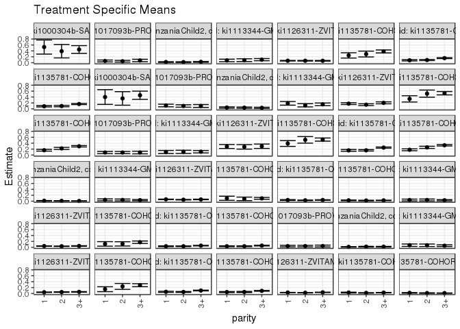

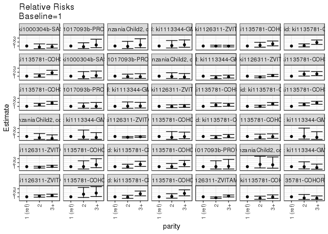

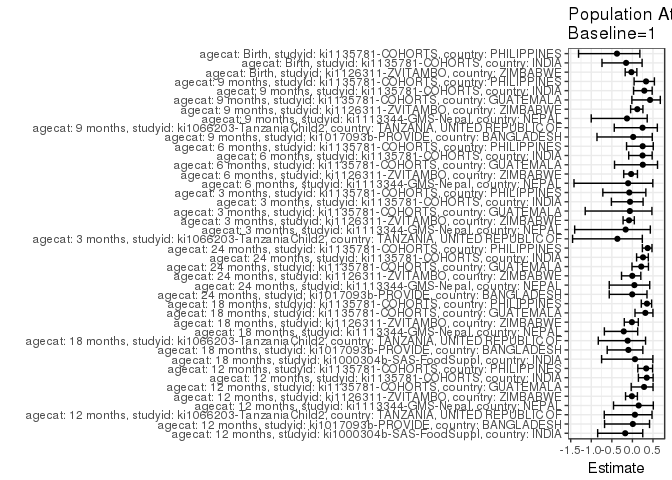

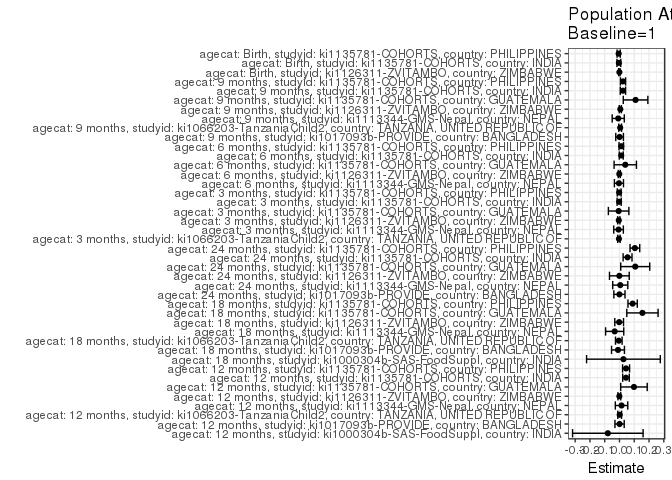

## Results Table

### Parameter: TSM

| agecat | studyid | country | intervention_level | baseline_level | estimate | ci_lower | ci_upper |
| --- | --- | --- | --- | --- | --- | --- | --- |
| Birth | ki1126311-ZVITAMBO | ZIMBABWE | 1 | NA | 0.0326524 | 0.0281447 | 0.0371601 |
| Birth | ki1126311-ZVITAMBO | ZIMBABWE | 2 | NA | 0.0249697 | 0.0202079 | 0.0297315 |
| Birth | ki1126311-ZVITAMBO | ZIMBABWE | 3+ | NA | 0.0383173 | 0.0321583 | 0.0444762 |
| Birth | ki1135781-COHORTS | INDIA | 1 | NA | 0.0316092 | 0.0186096 | 0.0446087 |
| Birth | ki1135781-COHORTS | INDIA | 2 | NA | 0.0202507 | 0.0116766 | 0.0288248 |
| Birth | ki1135781-COHORTS | INDIA | 3+ | NA | 0.0293010 | 0.0225374 | 0.0360645 |
| Birth | ki1135781-COHORTS | PHILIPPINES | 1 | NA | 0.0207407 | 0.0099878 | 0.0314937 |
| Birth | ki1135781-COHORTS | PHILIPPINES | 2 | NA | 0.0145560 | 0.0055987 | 0.0235134 |
| Birth | ki1135781-COHORTS | PHILIPPINES | 3+ | NA | 0.0130332 | 0.0076218 | 0.0184446 |
| 3 months | ki1066203-TanzaniaChild2 | TANZANIA, UNITED REPUBLIC OF | 1 | NA | 0.0138714 | 0.0057293 | 0.0220134 |
| 3 months | ki1066203-TanzaniaChild2 | TANZANIA, UNITED REPUBLIC OF | 2 | NA | 0.0094595 | 0.0024836 | 0.0164353 |
| 3 months | ki1066203-TanzaniaChild2 | TANZANIA, UNITED REPUBLIC OF | 3+ | NA | 0.0068493 | 0.0008650 | 0.0128336 |
| 3 months | ki1113344-GMS-Nepal | NEPAL | 1 | NA | 0.0448718 | 0.0123568 | 0.0773868 |
| 3 months | ki1113344-GMS-Nepal | NEPAL | 2 | NA | 0.0405405 | 0.0087384 | 0.0723427 |
| 3 months | ki1113344-GMS-Nepal | NEPAL | 3+ | NA | 0.0337079 | 0.0120412 | 0.0553746 |
| 3 months | ki1126311-ZVITAMBO | ZIMBABWE | 1 | NA | 0.0619035 | 0.0541034 | 0.0697035 |
| 3 months | ki1126311-ZVITAMBO | ZIMBABWE | 2 | NA | 0.0497512 | 0.0417173 | 0.0577852 |
| 3 months | ki1126311-ZVITAMBO | ZIMBABWE | 3+ | NA | 0.0586499 | 0.0498046 | 0.0674953 |
| 3 months | ki1135781-COHORTS | GUATEMALA | 1 | NA | 0.0985915 | 0.0291758 | 0.1680073 |
| 3 months | ki1135781-COHORTS | GUATEMALA | 2 | NA | 0.0779221 | 0.0179878 | 0.1378564 |
| 3 months | ki1135781-COHORTS | GUATEMALA | 3+ | NA | 0.0950920 | 0.0632154 | 0.1269686 |
| 3 months | ki1135781-COHORTS | INDIA | 1 | NA | 0.0391892 | 0.0252067 | 0.0531717 |
| 3 months | ki1135781-COHORTS | INDIA | 2 | NA | 0.0294118 | 0.0195244 | 0.0392991 |
| 3 months | ki1135781-COHORTS | INDIA | 3+ | NA | 0.0398406 | 0.0321883 | 0.0474930 |
| 3 months | ki1135781-COHORTS | PHILIPPINES | 1 | NA | 0.0276873 | 0.0147071 | 0.0406675 |
| 3 months | ki1135781-COHORTS | PHILIPPINES | 2 | NA | 0.0218750 | 0.0105404 | 0.0332096 |
| 3 months | ki1135781-COHORTS | PHILIPPINES | 3+ | NA | 0.0265268 | 0.0187027 | 0.0343510 |
| 6 months | ki1113344-GMS-Nepal | NEPAL | 1 | NA | 0.0392157 | 0.0084312 | 0.0700001 |
| 6 months | ki1113344-GMS-Nepal | NEPAL | 2 | NA | 0.0402685 | 0.0086749 | 0.0718620 |
| 6 months | ki1113344-GMS-Nepal | NEPAL | 3+ | NA | 0.0306513 | 0.0097209 | 0.0515818 |

[output cut: 96 more lines]

### Parameter: E(Y)

| agecat | studyid | country | intervention_level | baseline_level | estimate | ci_lower | ci_upper |
| --- | --- | --- | --- | --- | --- | --- | --- |
| Birth | ki1126311-ZVITAMBO | ZIMBABWE | NA | NA | 0.0318895 | 0.0318050 | 0.0319740 |
| Birth | ki1135781-COHORTS | INDIA | NA | NA | 0.0274139 | 0.0272845 | 0.0275432 |
| Birth | ki1135781-COHORTS | PHILIPPINES | NA | NA | 0.0150820 | 0.0149727 | 0.0151912 |
| 3 months | ki1066203-TanzaniaChild2 | TANZANIA, UNITED REPUBLIC OF | NA | NA | 0.0101635 | 0.0100432 | 0.0102838 |
| 3 months | ki1113344-GMS-Nepal | NEPAL | NA | NA | 0.0385289 | 0.0381360 | 0.0389218 |
| 3 months | ki1126311-ZVITAMBO | ZIMBABWE | NA | NA | 0.0572237 | 0.0571186 | 0.0573288 |
| 3 months | ki1135781-COHORTS | GUATEMALA | NA | NA | 0.0928270 | 0.0922252 | 0.0934288 |
| 3 months | ki1135781-COHORTS | INDIA | NA | NA | 0.0370540 | 0.0369207 | 0.0371873 |
| 3 months | ki1135781-COHORTS | PHILIPPINES | NA | NA | 0.0257391 | 0.0256617 | 0.0258166 |
| 6 months | ki1113344-GMS-Nepal | NEPAL | NA | NA | 0.0355240 | 0.0351481 | 0.0358998 |
| 6 months | ki1126311-ZVITAMBO | ZIMBABWE | NA | NA | 0.0417169 | 0.0416395 | 0.0417943 |
| 6 months | ki1135781-COHORTS | GUATEMALA | NA | NA | 0.1551724 | 0.1527817 | 0.1575632 |
| 6 months | ki1135781-COHORTS | INDIA | NA | NA | 0.0484735 | 0.0481635 | 0.0487836 |
| 6 months | ki1135781-COHORTS | PHILIPPINES | NA | NA | 0.0487445 | 0.0483371 | 0.0491518 |
| 9 months | ki1017093b-PROVIDE | BANGLADESH | NA | NA | 0.0413223 | 0.0412188 | 0.0414258 |
| 9 months | ki1066203-TanzaniaChild2 | TANZANIA, UNITED REPUBLIC OF | NA | NA | 0.0192744 | 0.0191084 | 0.0194404 |
| 9 months | ki1113344-GMS-Nepal | NEPAL | NA | NA | 0.0635209 | 0.0628496 | 0.0641921 |
| 9 months | ki1126311-ZVITAMBO | ZIMBABWE | NA | NA | 0.0480844 | 0.0479670 | 0.0482019 |
| 9 months | ki1135781-COHORTS | GUATEMALA | NA | NA | 0.2538631 | 0.2493897 | 0.2583366 |
| 9 months | ki1135781-COHORTS | INDIA | NA | NA | 0.0806580 | 0.0799353 | 0.0813807 |
| 9 months | ki1135781-COHORTS | PHILIPPINES | NA | NA | 0.0722714 | 0.0715382 | 0.0730046 |
| 12 months | ki1000304b-SAS-FoodSuppl | INDIA | NA | NA | 0.4505495 | 0.4414865 | 0.4596124 |
| 12 months | ki1017093b-PROVIDE | BANGLADESH | NA | NA | 0.0600000 | 0.0591834 | 0.0608166 |
| 12 months | ki1066203-TanzaniaChild2 | TANZANIA, UNITED REPUBLIC OF | NA | NA | 0.0232068 | 0.0230300 | 0.0233835 |
| 12 months | ki1113344-GMS-Nepal | NEPAL | NA | NA | 0.0913978 | 0.0904799 | 0.0923158 |
| 12 months | ki1126311-ZVITAMBO | ZIMBABWE | NA | NA | 0.0662418 | 0.0662230 | 0.0662607 |
| 12 months | ki1135781-COHORTS | GUATEMALA | NA | NA | 0.3452158 | 0.3406324 | 0.3497991 |
| 12 months | ki1135781-COHORTS | INDIA | NA | NA | 0.1262079 | 0.1250786 | 0.1273372 |
| 12 months | ki1135781-COHORTS | PHILIPPINES | NA | NA | 0.1330754 | 0.1317026 | 0.1344482 |
| 18 months | ki1000304b-SAS-FoodSuppl | INDIA | NA | NA | 0.4268293 | 0.4172511 | 0.4364074 |
| 18 months | ki1017093b-PROVIDE | BANGLADESH | NA | NA | 0.1032609 | 0.1026214 | 0.1039003 |
| 18 months | ki1066203-TanzaniaChild2 | TANZANIA, UNITED REPUBLIC OF | NA | NA | 0.0403727 | 0.0401204 | 0.0406249 |
| 18 months | ki1113344-GMS-Nepal | NEPAL | NA | NA | 0.1545455 | 0.1525049 | 0.1565860 |
| 18 months | ki1126311-ZVITAMBO | ZIMBABWE | NA | NA | 0.1743710 | 0.1731996 | 0.1755423 |
| 18 months | ki1135781-COHORTS | GUATEMALA | NA | NA | 0.4931193 | 0.4863381 | 0.4999004 |
| 18 months | ki1135781-COHORTS | PHILIPPINES | NA | NA | 0.2516051 | 0.2494625 | 0.2537478 |
| 24 months | ki1017093b-PROVIDE | BANGLADESH | NA | NA | 0.0849220 | 0.0848939 | 0.0849501 |
| 24 months | ki1113344-GMS-Nepal | NEPAL | NA | NA | 0.1082164 | 0.1079002 | 0.1085327 |
| 24 months | ki1126311-ZVITAMBO | ZIMBABWE | NA | NA | 0.2872807 | 0.2865443 | 0.2880171 |
| 24 months | ki1135781-COHORTS | GUATEMALA | NA | NA | 0.4961390 | 0.4917734 | 0.5005046 |
| 24 months | ki1135781-COHORTS | INDIA | NA | NA | 0.2122377 | 0.2106963 | 0.2137790 |
| 24 months | ki1135781-COHORTS | PHILIPPINES | NA | NA | 0.2817996 | 0.2793628 | 0.2842364 |

### Parameter: RR

| agecat | studyid | country | intervention_level | baseline_level | estimate | ci_lower | ci_upper |
| --- | --- | --- | --- | --- | --- | --- | --- |
| Birth | ki1126311-ZVITAMBO | ZIMBABWE | 1 | 1 | 1.0000000 | 1.0000000 | 1.0000000 |
| Birth | ki1126311-ZVITAMBO | ZIMBABWE | 2 | 1 | 0.7647130 | 0.6043028 | 0.9677035 |
| Birth | ki1126311-ZVITAMBO | ZIMBABWE | 3+ | 1 | 1.1734905 | 0.9494248 | 1.4504361 |
| Birth | ki1135781-COHORTS | INDIA | 1 | 1 | 1.0000000 | 1.0000000 | 1.0000000 |
| Birth | ki1135781-COHORTS | INDIA | 2 | 1 | 0.6406592 | 0.3550449 | 1.1560348 |
| Birth | ki1135781-COHORTS | INDIA | 3+ | 1 | 0.9269759 | 0.5784298 | 1.4855465 |
| Birth | ki1135781-COHORTS | PHILIPPINES | 1 | 1 | 1.0000000 | 1.0000000 | 1.0000000 |
| Birth | ki1135781-COHORTS | PHILIPPINES | 2 | 1 | 0.7018091 | 0.3138795 | 1.5691883 |
| Birth | ki1135781-COHORTS | PHILIPPINES | 3+ | 1 | 0.6283852 | 0.3234162 | 1.2209285 |
| 3 months | ki1066203-TanzaniaChild2 | TANZANIA, UNITED REPUBLIC OF | 1 | 1 | 1.0000000 | 1.0000000 | 1.0000000 |
| 3 months | ki1066203-TanzaniaChild2 | TANZANIA, UNITED REPUBLIC OF | 2 | 1 | 0.6819410 | 0.2657124 | 1.7501766 |
| 3 months | ki1066203-TanzaniaChild2 | TANZANIA, UNITED REPUBLIC OF | 3+ | 1 | 0.4937734 | 0.1723469 | 1.4146595 |
| 3 months | ki1113344-GMS-Nepal | NEPAL | 1 | 1 | 1.0000000 | 1.0000000 | 1.0000000 |
| 3 months | ki1113344-GMS-Nepal | NEPAL | 2 | 1 | 0.9034749 | 0.3105468 | 2.6284827 |
| 3 months | ki1113344-GMS-Nepal | NEPAL | 3+ | 1 | 0.7512039 | 0.2851597 | 1.9789164 |
| 3 months | ki1126311-ZVITAMBO | ZIMBABWE | 1 | 1 | 1.0000000 | 1.0000000 | 1.0000000 |
| 3 months | ki1126311-ZVITAMBO | ZIMBABWE | 2 | 1 | 0.8036908 | 0.6548387 | 0.9863787 |
| 3 months | ki1126311-ZVITAMBO | ZIMBABWE | 3+ | 1 | 0.9474421 | 0.7783994 | 1.1531952 |
| 3 months | ki1135781-COHORTS | GUATEMALA | 1 | 1 | 1.0000000 | 1.0000000 | 1.0000000 |
| 3 months | ki1135781-COHORTS | GUATEMALA | 2 | 1 | 0.7903525 | 0.2785873 | 2.2422313 |
| 3 months | ki1135781-COHORTS | GUATEMALA | 3+ | 1 | 0.9645048 | 0.4422221 | 2.1036252 |
| 3 months | ki1135781-COHORTS | INDIA | 1 | 1 | 1.0000000 | 1.0000000 | 1.0000000 |
| 3 months | ki1135781-COHORTS | INDIA | 2 | 1 | 0.7505071 | 0.4596810 | 1.2253299 |
| 3 months | ki1135781-COHORTS | INDIA | 3+ | 1 | 1.0166232 | 0.6779221 | 1.5245448 |
| 3 months | ki1135781-COHORTS | PHILIPPINES | 1 | 1 | 1.0000000 | 1.0000000 | 1.0000000 |
| 3 months | ki1135781-COHORTS | PHILIPPINES | 2 | 1 | 0.7900735 | 0.3928247 | 1.5890452 |
| 3 months | ki1135781-COHORTS | PHILIPPINES | 3+ | 1 | 0.9580869 | 0.5506266 | 1.6670654 |
| 6 months | ki1113344-GMS-Nepal | NEPAL | 1 | 1 | 1.0000000 | 1.0000000 | 1.0000000 |
| 6 months | ki1113344-GMS-Nepal | NEPAL | 2 | 1 | 1.0268456 | 0.3384542 | 3.1153756 |
| 6 months | ki1113344-GMS-Nepal | NEPAL | 3+ | 1 | 0.7816092 | 0.2761410 | 2.2123227 |

[output cut: 96 more lines]

### Parameter: PAR

| agecat | studyid | country | intervention_level | baseline_level | estimate | ci_lower | ci_upper |
| --- | --- | --- | --- | --- | --- | --- | --- |
| Birth | ki1126311-ZVITAMBO | ZIMBABWE | 1 | NA | -0.0007629 | -0.0052713 | 0.0037456 |
| Birth | ki1135781-COHORTS | INDIA | 1 | NA | -0.0041953 | -0.0171955 | 0.0088049 |
| Birth | ki1135781-COHORTS | PHILIPPINES | 1 | NA | -0.0056588 | -0.0164123 | 0.0050948 |
| 3 months | ki1066203-TanzaniaChild2 | TANZANIA, UNITED REPUBLIC OF | 1 | NA | -0.0037079 | -0.0118508 | 0.0044351 |
| 3 months | ki1113344-GMS-Nepal | NEPAL | 1 | NA | -0.0063429 | -0.0388603 | 0.0261745 |
| 3 months | ki1126311-ZVITAMBO | ZIMBABWE | 1 | NA | -0.0046798 | -0.0124806 | 0.0031210 |
| 3 months | ki1135781-COHORTS | GUATEMALA | 1 | NA | -0.0057645 | -0.0751829 | 0.0636538 |
| 3 months | ki1135781-COHORTS | INDIA | 1 | NA | -0.0021352 | -0.0161183 | 0.0118479 |
| 3 months | ki1135781-COHORTS | PHILIPPINES | 1 | NA | -0.0019482 | -0.0149286 | 0.0110323 |
| 6 months | ki1113344-GMS-Nepal | NEPAL | 1 | NA | -0.0036917 | -0.0344784 | 0.0270950 |
| 6 months | ki1126311-ZVITAMBO | ZIMBABWE | 1 | NA | -0.0012873 | -0.0082076 | 0.0056329 |
| 6 months | ki1135781-COHORTS | GUATEMALA | 1 | NA | 0.0392304 | -0.0364302 | 0.1148910 |
| 6 months | ki1135781-COHORTS | INDIA | 1 | NA | 0.0119871 | -0.0015272 | 0.0255013 |
| 6 months | ki1135781-COHORTS | PHILIPPINES | 1 | NA | 0.0121591 | -0.0032078 | 0.0275260 |
| 9 months | ki1017093b-PROVIDE | BANGLADESH | 1 | NA | 0.0007818 | -0.0251835 | 0.0267470 |
| 9 months | ki1066203-TanzaniaChild2 | TANZANIA, UNITED REPUBLIC OF | 1 | NA | 0.0047582 | -0.0046605 | 0.0141770 |
| 9 months | ki1113344-GMS-Nepal | NEPAL | 1 | NA | -0.0083746 | -0.0493482 | 0.0325991 |
| 9 months | ki1126311-ZVITAMBO | ZIMBABWE | 1 | NA | 0.0057199 | -0.0014356 | 0.0128754 |
| 9 months | ki1135781-COHORTS | GUATEMALA | 1 | NA | 0.1089356 | 0.0256619 | 0.1922093 |
| 9 months | ki1135781-COHORTS | INDIA | 1 | NA | 0.0233825 | 0.0054467 | 0.0413182 |
| 9 months | ki1135781-COHORTS | PHILIPPINES | 1 | NA | 0.0239955 | 0.0065326 | 0.0414585 |
| 12 months | ki1000304b-SAS-FoodSuppl | INDIA | 1 | NA | -0.0788623 | -0.3176179 | 0.1598933 |
| 12 months | ki1017093b-PROVIDE | BANGLADESH | 1 | NA | 0.0006393 | -0.0306934 | 0.0319719 |
| 12 months | ki1066203-TanzaniaChild2 | TANZANIA, UNITED REPUBLIC OF | 1 | NA | 0.0014246 | -0.0113124 | 0.0141615 |
| 12 months | ki1113344-GMS-Nepal | NEPAL | 1 | NA | 0.0139785 | -0.0281428 | 0.0560998 |
| 12 months | ki1126311-ZVITAMBO | ZIMBABWE | 1 | NA | -0.0008267 | -0.0103441 | 0.0086906 |
| 12 months | ki1135781-COHORTS | GUATEMALA | 1 | NA | 0.0980247 | 0.0082021 | 0.1878474 |
| 12 months | ki1135781-COHORTS | INDIA | 1 | NA | 0.0440161 | 0.0217085 | 0.0663237 |
| 12 months | ki1135781-COHORTS | PHILIPPINES | 1 | NA | 0.0446278 | 0.0209391 | 0.0683165 |
| 18 months | ki1000304b-SAS-FoodSuppl | INDIA | 1 | NA | 0.0268293 | -0.2227982 | 0.2764568 |
| 18 months | ki1017093b-PROVIDE | BANGLADESH | 1 | NA | -0.0100396 | -0.0536856 | 0.0336064 |
| 18 months | ki1066203-TanzaniaChild2 | TANZANIA, UNITED REPUBLIC OF | 1 | NA | -0.0046724 | -0.0269615 | 0.0176168 |
| 18 months | ki1113344-GMS-Nepal | NEPAL | 1 | NA | -0.0325513 | -0.0940363 | 0.0289337 |
| 18 months | ki1126311-ZVITAMBO | ZIMBABWE | 1 | NA | -0.0021915 | -0.0317642 | 0.0273812 |
| 18 months | ki1135781-COHORTS | GUATEMALA | 1 | NA | 0.1554569 | 0.0494892 | 0.2614246 |
| 18 months | ki1135781-COHORTS | PHILIPPINES | 1 | NA | 0.0890342 | 0.0575126 | 0.1205559 |
| 24 months | ki1017093b-PROVIDE | BANGLADESH | 1 | NA | -0.0003860 | -0.0381099 | 0.0373378 |
| 24 months | ki1113344-GMS-Nepal | NEPAL | 1 | NA | 0.0052753 | -0.0458491 | 0.0563996 |
| 24 months | ki1126311-ZVITAMBO | ZIMBABWE | 1 | NA | -0.0008549 | -0.0676526 | 0.0659428 |
| 24 months | ki1135781-COHORTS | GUATEMALA | 1 | NA | 0.1066653 | 0.0084167 | 0.2049139 |
| 24 months | ki1135781-COHORTS | INDIA | 1 | NA | 0.0547155 | 0.0246334 | 0.0847977 |
| 24 months | ki1135781-COHORTS | PHILIPPINES | 1 | NA | 0.1043187 | 0.0715076 | 0.1371298 |

### Parameter: PAF

| agecat | studyid | country | intervention_level | baseline_level | estimate | ci_lower | ci_upper |
| --- | --- | --- | --- | --- | --- | --- | --- |
| Birth | ki1126311-ZVITAMBO | ZIMBABWE | 1 | NA | -0.0239223 | -0.1755269 | 0.1081303 |
| Birth | ki1135781-COHORTS | INDIA | 1 | NA | -0.1530363 | -0.7396504 | 0.2357702 |
| Birth | ki1135781-COHORTS | PHILIPPINES | 1 | NA | -0.3752013 | -1.3096533 | 0.1811851 |
| 3 months | ki1066203-TanzaniaChild2 | TANZANIA, UNITED REPUBLIC OF | 1 | NA | -0.3648226 | -1.4549636 | 0.2412349 |
| 3 months | ki1113344-GMS-Nepal | NEPAL | 1 | NA | -0.1646270 | -1.4039014 | 0.4357688 |
| 3 months | ki1126311-ZVITAMBO | ZIMBABWE | 1 | NA | -0.0817807 | -0.2270652 | 0.0463022 |
| 3 months | ki1135781-COHORTS | GUATEMALA | 1 | NA | -0.0620999 | -1.1476025 | 0.4747370 |
| 3 months | ki1135781-COHORTS | INDIA | 1 | NA | -0.0576243 | -0.5110993 | 0.2597647 |
| 3 months | ki1135781-COHORTS | PHILIPPINES | 1 | NA | -0.0756889 | -0.7190755 | 0.3269018 |
| 6 months | ki1113344-GMS-Nepal | NEPAL | 1 | NA | -0.1039216 | -1.4204258 | 0.4965172 |
| 6 months | ki1126311-ZVITAMBO | ZIMBABWE | 1 | NA | -0.0308589 | -0.2108393 | 0.1223691 |
| 6 months | ki1135781-COHORTS | GUATEMALA | 1 | NA | 0.2528180 | -0.4347380 | 0.6108830 |
| 6 months | ki1135781-COHORTS | INDIA | 1 | NA | 0.2472908 | -0.0901029 | 0.4802590 |
| 6 months | ki1135781-COHORTS | PHILIPPINES | 1 | NA | 0.2494457 | -0.1422728 | 0.5068325 |
| 9 months | ki1017093b-PROVIDE | BANGLADESH | 1 | NA | 0.0189189 | -0.8614869 | 0.4829294 |
| 9 months | ki1066203-TanzaniaChild2 | TANZANIA, UNITED REPUBLIC OF | 1 | NA | 0.2468691 | -0.4409275 | 0.6063604 |
| 9 months | ki1113344-GMS-Nepal | NEPAL | 1 | NA | -0.1318394 | -1.0012485 | 0.3598694 |
| 9 months | ki1126311-ZVITAMBO | ZIMBABWE | 1 | NA | 0.1189555 | -0.0431572 | 0.2558749 |
| 9 months | ki1135781-COHORTS | GUATEMALA | 1 | NA | 0.4291115 | -0.0135591 | 0.6784463 |
| 9 months | ki1135781-COHORTS | INDIA | 1 | NA | 0.2898963 | 0.0288963 | 0.4807483 |
| 9 months | ki1135781-COHORTS | PHILIPPINES | 1 | NA | 0.3320197 | 0.0410731 | 0.5346906 |
| 12 months | ki1000304b-SAS-FoodSuppl | INDIA | 1 | NA | -0.1750359 | -0.8448631 | 0.2515926 |
| 12 months | ki1017093b-PROVIDE | BANGLADESH | 1 | NA | 0.0106545 | -0.6771887 | 0.4164017 |
| 12 months | ki1066203-TanzaniaChild2 | TANZANIA, UNITED REPUBLIC OF | 1 | NA | 0.0613861 | -0.6843571 | 0.4769541 |
| 12 months | ki1113344-GMS-Nepal | NEPAL | 1 | NA | 0.1529412 | -0.4594290 | 0.5083634 |
| 12 months | ki1126311-ZVITAMBO | ZIMBABWE | 1 | NA | -0.0124804 | -0.1668498 | 0.1214665 |
| 12 months | ki1135781-COHORTS | GUATEMALA | 1 | NA | 0.2839521 | -0.0295631 | 0.5019979 |
| 12 months | ki1135781-COHORTS | INDIA | 1 | NA | 0.3487589 | 0.1458655 | 0.5034564 |
| 12 months | ki1135781-COHORTS | PHILIPPINES | 1 | NA | 0.3353570 | 0.1314489 | 0.4913940 |
| 18 months | ki1000304b-SAS-FoodSuppl | INDIA | 1 | NA | 0.0628571 | -0.7490858 | 0.4978881 |
| 18 months | ki1017093b-PROVIDE | BANGLADESH | 1 | NA | -0.0972258 | -0.6128728 | 0.2535651 |
| 18 months | ki1066203-TanzaniaChild2 | TANZANIA, UNITED REPUBLIC OF | 1 | NA | -0.1157311 | -0.8300384 | 0.3197651 |
| 18 months | ki1113344-GMS-Nepal | NEPAL | 1 | NA | -0.2106262 | -0.6817733 | 0.1285295 |
| 18 months | ki1126311-ZVITAMBO | ZIMBABWE | 1 | NA | -0.0125682 | -0.1971987 | 0.1435889 |
| 18 months | ki1135781-COHORTS | GUATEMALA | 1 | NA | 0.3152522 | 0.0631375 | 0.4995215 |
| 18 months | ki1135781-COHORTS | PHILIPPINES | 1 | NA | 0.3538650 | 0.2158173 | 0.4676107 |
| 24 months | ki1017093b-PROVIDE | BANGLADESH | 1 | NA | -0.0045459 | -0.5632126 | 0.3544624 |
| 24 months | ki1113344-GMS-Nepal | NEPAL | 1 | NA | 0.0487473 | -0.5630826 | 0.4210915 |
| 24 months | ki1126311-ZVITAMBO | ZIMBABWE | 1 | NA | -0.0029758 | -0.2646544 | 0.2045570 |
| 24 months | ki1135781-COHORTS | GUATEMALA | 1 | NA | 0.2149908 | -0.0101557 | 0.3899560 |
| 24 months | ki1135781-COHORTS | INDIA | 1 | NA | 0.2578031 | 0.1017280 | 0.3867601 |
| 24 months | ki1135781-COHORTS | PHILIPPINES | 1 | NA | 0.3701875 | 0.2425287 | 0.4763315 |